# Pratical Machine Learning - Final Project

Steven Zylinski

Created: 2019-03-12; Last updated:2019-03-20

# Project Purpose

The goal of the project is to predict how well they did the exercice (classe variable). In this report, I am told to :

- Describe how I build the model
- How I use cross validation
- What I think the expected out of sample error is
- Why I made the choice I did

Then I should use my model to predict 20 different test cases

# Pre-Processing

## Loading the data and creating a validation data set

We create a dataset of validation based on the training dataset in order to calibrate our model

```r
set.seed(2806)
 train <- read.csv("~/Desktop/pml-training.csv",na.strings=c("#DIV/0!","NA",""))
 test <- read.csv("~/Desktop/pml-testing.csv",na.strings=c("#DIV/0!","NA",""))
```

## Cleaning features

First we start by removing *id type features* :

```r
train <- train[,-c(1:5)]
test <- test[,-c(1:5)]
```

Then we remove features that have *Near Zero Variance* :

```r
NZV <- nearZeroVar(train)
train <- train[,-NZV]
test <- test[,-NZV]
```

Finally we remove features that are almost always *NA* :

```r
# We take all feature that have an average of NA greater than 90 %

FullNA <- sapply(train,function(x) mean(is.na(x))) > .90
train <- train[,FullNA==FALSE]
test <- test[,FullNA==FALSE]
```

## Partitionning Data

In order to evaluate my out of sample error, I am going to split my train data between a train dataset and a validation dataset :

```r
 inTrain <- createDataPartition(train$classe,p = 3/4)[[1]]
 validation <- train[-inTrain,]
 train <- train[inTrain,]
```

## Model

### Decision Tree

Let’s start with a simple decision tree :

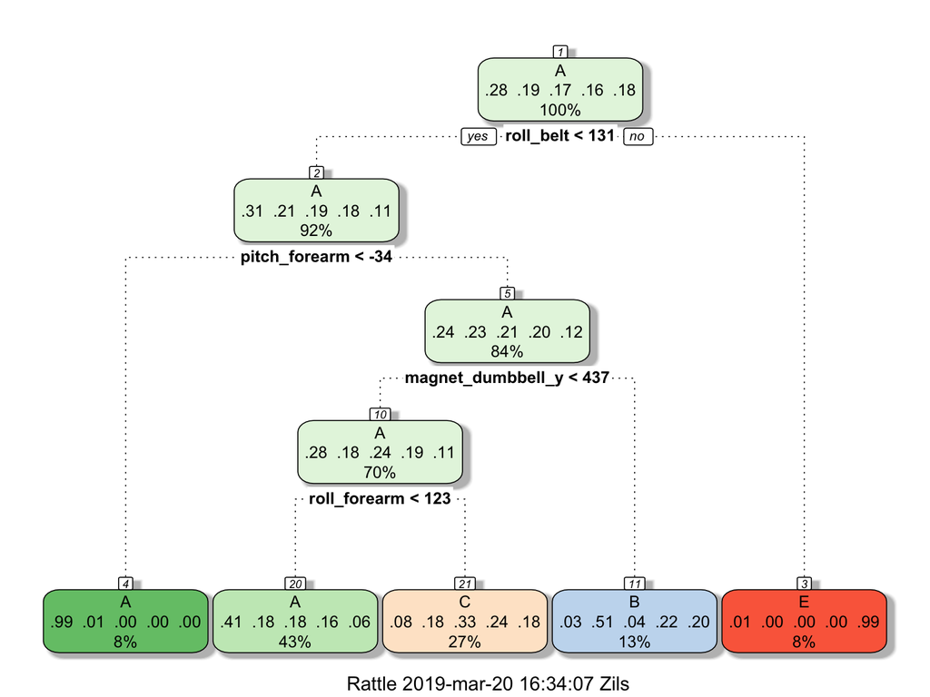

```r
fitDT <- train(classe~., data = train, method = "rpart")
fancyRpartPlot(fitDT$finalModel)
```

Let’s evaluate this model on our validation dataset :

```r
predictDT <- predict(fitDT,validation)
confusionMatrix(predictDT,validation$classe)
```

```
## Confusion Matrix and Statistics
##
##           Reference
## Prediction    A    B    C    D    E
##          A 1258  386  411  383  123
##          B   29  319   28  146  113
##          C  107  244  416  275  260
##          D    0    0    0    0    0
##          E    1    0    0    0  405
##
## Overall Statistics
##
##                Accuracy : 0.489
##                  95% CI : (0.4749, 0.5031)
##     No Information Rate : 0.2845
##     P-Value [Acc > NIR] : < 2.2e-16
##
##                   Kappa : 0.3319
##  Mcnemar's Test P-Value : NA
##
## Statistics by Class:
##
##                      Class: A Class: B Class: C Class: D Class: E
## Sensitivity            0.9018  0.33614  0.48655   0.0000  0.44950
## Specificity            0.6287  0.92010  0.78118   1.0000  0.99975
## Pos Pred Value         0.4912  0.50236  0.31951      NaN  0.99754
## Neg Pred Value         0.9415  0.85242  0.87812   0.8361  0.88973
## Prevalence             0.2845  0.19352  0.17435   0.1639  0.18373
## Detection Rate         0.2565  0.06505  0.08483   0.0000  0.08259
## Detection Prevalence   0.5222  0.12949  0.26550   0.0000  0.08279
## Balanced Accuracy      0.7652  0.62812  0.63387   0.5000  0.72463
```

A single decision tree doesn’t seems enough to predict correctly classes. Let’s use multiple trees !

### RandomForest

First let’s train our Random Forest on our train dataset. In order to select optimal tuning parameter, we use a cross-validation method :

```r
myControl <- trainControl(method = "cv",number = 4,verboseIter = FALSE)
fitRF <- train(classe ~., data = train,method = "rf", trControl = myControl)
```

Let’s have a quick look at our model :

```r
fitRF$finalModel
```

```
##
## Call:
##  randomForest(x = x, y = y, mtry = param$mtry)
##                Type of random forest: classification
##                      Number of trees: 500
## No. of variables tried at each split: 27
##
##         OOB estimate of  error rate: 0.21%
## Confusion matrix:
##      A    B    C    D    E  class.error
## A 4183    1    0    0    1 0.0004778973
## B    4 2841    2    1    0 0.0024578652
## C    0    7 2559    1    0 0.0031164784
## D    0    0    7 2404    1 0.0033167496
## E    0    1    0    5 2700 0.0022172949
```

And then evaluate the model on our validation dataset :

```r
predictRF <- predict(fitRF,validation)
confusionMatrix(predictRF,validation$classe)
```

```
## Confusion Matrix and Statistics
##
##           Reference
## Prediction    A    B    C    D    E
##          A 1395    3    0    0    0
##          B    0  946    0    0    0
##          C    0    0  855    5    0
##          D    0    0    0  799    0
##          E    0    0    0    0  901
##
## Overall Statistics
##
##                Accuracy : 0.9984
##                  95% CI : (0.9968, 0.9993)
##     No Information Rate : 0.2845
##     P-Value [Acc > NIR] : < 2.2e-16
##
##                   Kappa : 0.9979
##  Mcnemar's Test P-Value : NA
##
## Statistics by Class:
##
##                      Class: A Class: B Class: C Class: D Class: E
## Sensitivity            1.0000   0.9968   1.0000   0.9938   1.0000
## Specificity            0.9991   1.0000   0.9988   1.0000   1.0000
## Pos Pred Value         0.9979   1.0000   0.9942   1.0000   1.0000
## Neg Pred Value         1.0000   0.9992   1.0000   0.9988   1.0000
## Prevalence             0.2845   0.1935   0.1743   0.1639   0.1837
## Detection Rate         0.2845   0.1929   0.1743   0.1629   0.1837
## Detection Prevalence   0.2851   0.1929   0.1754   0.1629   0.1837
## Balanced Accuracy      0.9996   0.9984   0.9994   0.9969   1.0000
```

Much much better ! But such a high accuracy could be meaning that we are overfitting data. Let’s try a GBM model in order to comparer performance.

### GBM

Let’s train our model using again a cross validation method to tune our hyper parameters :

```r
myControlGB <- trainControl(method = "cv", number = 4, verboseIter = FALSE)
fitGBM <- train(classe~., data = train , method = "gbm", trControl = myControlGB, verbose = FALSE)
```

Finally let’s see how well it performed :

```r
predictGBM <- predict(fitGBM,validation)
confusionMatrix(predictGBM,validation$classe)
```

```
## Confusion Matrix and Statistics
##
##           Reference
## Prediction    A    B    C    D    E
##          A 1395    7    0    0    0
##          B    0  938    9    2    6
##          C    0    4  844   11    3
##          D    0    0    1  791    5
##          E    0    0    1    0  887
##
## Overall Statistics
##
##                Accuracy : 0.99
##                  95% CI : (0.9868, 0.9926)
##     No Information Rate : 0.2845
##     P-Value [Acc > NIR] : < 2.2e-16
##
##                   Kappa : 0.9874
##  Mcnemar's Test P-Value : NA
##
## Statistics by Class:
##
##                      Class: A Class: B Class: C Class: D Class: E
## Sensitivity            1.0000   0.9884   0.9871   0.9838   0.9845
## Specificity            0.9980   0.9957   0.9956   0.9985   0.9998
## Pos Pred Value         0.9950   0.9822   0.9791   0.9925   0.9989
## Neg Pred Value         1.0000   0.9972   0.9973   0.9968   0.9965
## Prevalence             0.2845   0.1935   0.1743   0.1639   0.1837
## Detection Rate         0.2845   0.1913   0.1721   0.1613   0.1809
## Detection Prevalence   0.2859   0.1947   0.1758   0.1625   0.1811
## Balanced Accuracy      0.9990   0.9921   0.9913   0.9912   0.9921
```

# Conclusion

Even if RandomForest has the highest accuracy rate (and therefor supposely the lowest out of sample error), I decided to use the GBM model to predict classes for the test dataset in order to avoid the overfitting.

```r
final <- predict(fitGBM,test)
final
```

```
##  [1] B A B A A E D B A A B C B A E E A B B B
## Levels: A B C D E
```